# Presentation handout

Author

Adham Rishmawi

## Economic Question

Q. **do the programs affect the individual’s intellectuality and yield where it makes sure that there is less food deprivation occurring more often. (is there a association between food_ran_out and increased_knowledge and increased_yield?)**

## Predictors

- `Increased_Knowledge` and `Increased_Yield`
  - Justification: This i thought would be a great predictor to pair up with increase_yield because they are both binary options which we can study instances where both are either 1 or zeros and see how they influence my response variable.
- `Age_Group`
  - Justification: this an additional predictor that i thought would influence my response variable because certain ages might be a contributor to the reason why they ran out of food or the reason their knowledge changed differently so I included it.
- `Gender`
  - Justification: this was a included because I believe cultural aspects and circumstances would alter the rates at which people ran out of food and learned.
- `(1|Partner)`
  - Justification: the Random effects I based it on The Partner because i believed it would be a bad traditional predictor because all the Organizations included have the same goal so theoretical it should be a bad predictor. It also fits the criteria we said in class that it must be a location, time, or identity which it is. I did not get any convergence problems so that’s a good identification that it is a good RE effect.
- All other columns and variables:
  - Justification: I wanted to stay within the rule of thumb for this test and make sure that my predictors did not go beyond the threshold. Other predictors would have played into distorting the correlation between my response variable and predictors.

## Model

```
 Family: binomial  ( logit )
Formula:
factor(Food_Ran_Out) ~ Increased_Knowledge * Increased_Yield +
    Age_Group + Gender + (1 | Partner)
Data: data1

     AIC      BIC   logLik deviance df.resid
   256.5    282.4   -120.3    240.5      180

Random effects:

Conditional model:
 Groups  Name        Variance Std.Dev.
 Partner (Intercept) 1.669    1.292
Number of obs: 188, groups:  Partner, 10

Conditional model:
                                    Estimate Std. Error z value Pr(>|z|)
(Intercept)                         -1.05722    1.04453  -1.012   0.3115
Increased_Knowledge                  0.62317    1.16513   0.535   0.5928
Increased_Yield                     -0.14140    0.77976  -0.181   0.8561
Age_Group50_plus                    -0.83572    0.38542  -2.168   0.0301 *
Age_Groupunder_30                   -0.73642    0.44092  -1.670   0.0949 .
Gendermale                          -0.03445    0.33332  -0.103   0.9177
Increased_Knowledge:Increased_Yield -0.25721    1.19300  -0.216   0.8293
---
Signif. codes:  0 '***' 0.001 '**' 0.01 '*' 0.05 '.' 0.1 ' ' 1
```

## Graphs

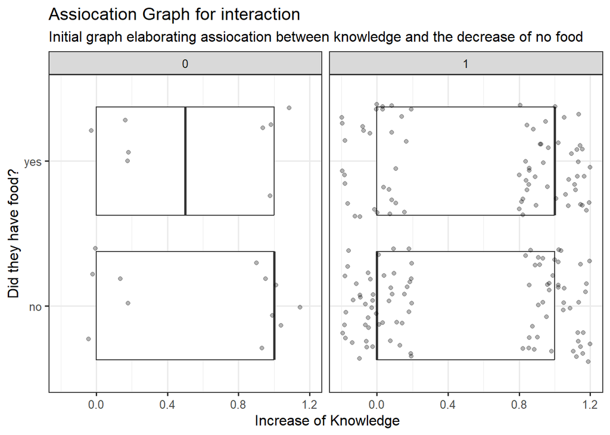

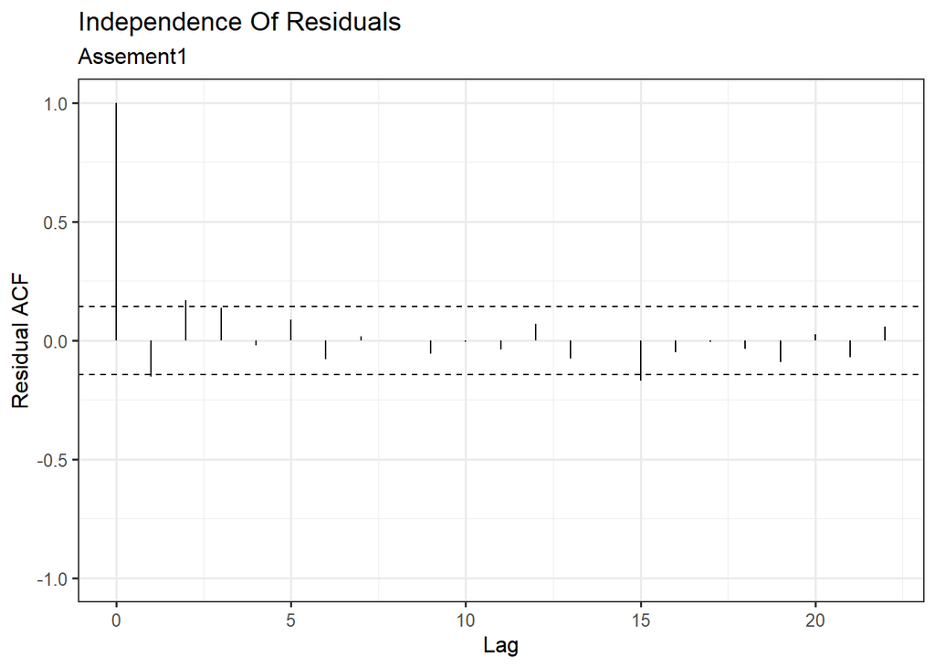

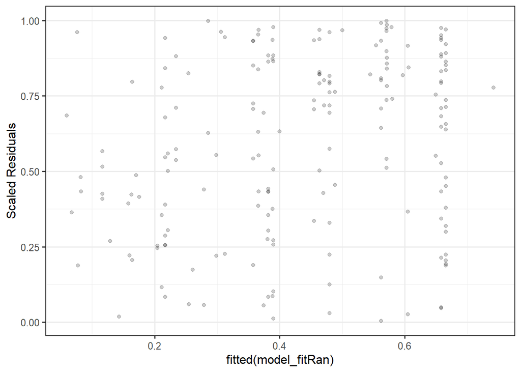

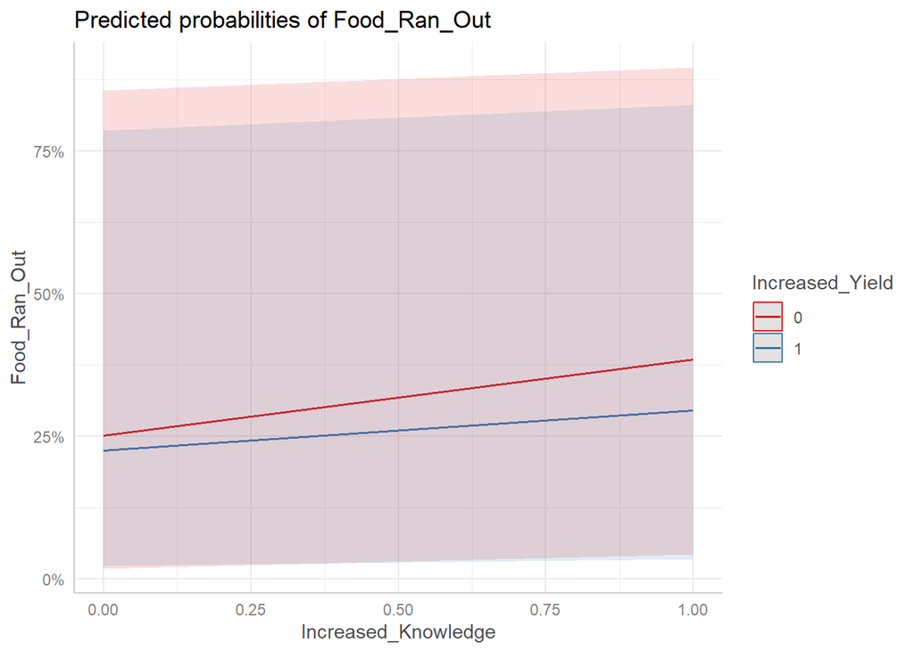